# crude_genes_stats

started: Alexey Larionov, 27Feb2017  
last updated: Alexey Larionov, 19Sep2019

# Summary

162 variants -> 62 genes

Make a data frame with gene-level aggregated crude statistics:

- Fisher tests for NFE vs BC
- Fisher test for UBC vs CBC
- prop.trend.test for NFE:UBC:CBC along with 1:2:3 scores

### Explore crude aggregated stats per gene

Mean agregated MAC: 5.8  
Median agregated MAC: 3

qq-plots involving NFE (NFE-vs-BC and NFE-UBC-CBC trend) show p-values reasonably close to expected under H0.  
The deflation for UBC-vs-CBC may reflect low numbers of cases and low counts of variants with AF < 0.05

### Input data:

- 162 variants x 664 samples (467BC = 232UBC + 235CBC and 197NFE)

### Output data:

- 162 variants x 664 samples
- 62 genes x 664 samples

### Overall:

No significantly associated genes after multiple testing correction

```r
# Time stamp
Sys.time()
```

```
## [1] "2019-09-19 18:25:35 BST"
```

```r
# Clenan-up
rm(list=ls())
graphics.off()

# Base folder
library(knitr)
base_folder="/Users/alexey/Documents/wecare/ampliseq/v04_ampliseq_nfe/s16_crude_stats"
opts_knit$set(root.dir = base_folder)
#setwd(base_folder)

# Load libraries
library(dplyr)
library(QQperm)
# Accessory function
source(paste(base_folder, "f01_qqunif_plot.R", sep="/"))
```

# load_data

```r
load(paste(base_folder, "s01_crude_variants_stats.RData", sep="/"))
```

# check_data

```r
ls()
```

```
## [1] "base_folder"   "genotypes.mx"  "phenotypes.df" "qqunif.plot"   "variants.df"
```

```r
dim(genotypes.mx)
```

```
## [1] 162 664
```

```r
dim(variants.df)
```

```
## [1] 162  87
```

```r
dim(phenotypes.df)
```

```
## [1] 664  31
```

```r
# Check consistency of rownames and colnames
sum(colnames(genotypes.mx) != rownames(phenotypes.df))
```

```
## [1] 0
```

```r
sum(rownames(genotypes.mx) != rownames(variants.df))
```

```
## [1] 0
```

# Get raw stats per gene

Record if multilaalelic variant is present in a gene.  
Calculate Fisher-exact tests and trend in proportion for raw counts.  
Note that trends in raw counts are evaluated **BEFORE** imputation.  
The result is still in character matrix that need to be converted to df with appropriate data types.

```r
# Get list of genes
# (check that there is no NAs; get rid of NAs if they are present!)
genes <- unique(as.character(variants.df$SYMBOL))
length(genes)
```

```
## [1] 62
```

```r
sum(is.na(genes))
```

```
## [1] 0
```

```r
# Prepare blank matrix for output
header <- c("gene", "num_var", "multiallelic",
            "aggr_ac", "aggr_an", "aggr_af",
            "aggr_ac_nfe", "aggr_an_nfe", "aggr_af_nfe",
            "aggr_ac_bc", "aggr_an_bc", "aggr_af_bc",
            "aggr_ac_cbc", "aggr_an_cbc", "aggr_af_cbc",
            "aggr_ac_ubc", "aggr_an_ubc", "aggr_af_ubc",
            "nfe_bc_fisher_p", "ubc_cbc_fisher_p", "prop_trend_p", "crude_trend_direction")

genes.mx <- matrix(nrow=0, ncol=length(header))
header -> colnames(genes.mx)

# Make logical vectors for the subgroups
table(phenotypes.df$cc)
```

```
##
##  -1   0   1
## 197 232 235
```

```r
nfe_cases <- phenotypes.df$cc == -1
bc_cases <- phenotypes.df$cc != -1
ubc_cases <- phenotypes.df$cc == 0
cbc_cases <- phenotypes.df$cc == 1

#genes <- c("EPHB2","SZT2") # for testing

# For each gene
for(gene in genes){

  #gene="EPHB2" # 1 var # for testing
  #gene="SZT2" # 5 vars # for testing

  # Get list of variants
  vars <- variants.df$SYMBOL == gene

  # Count variants
  num_var <- sum(vars)

  # Check if any variant is multiallelic
  multiallelic <- (any(variants.df[vars, "Multiallelic"]))

  # Get genotypes matrices for subgroups
  gt.mx <- genotypes.mx[vars, , drop=FALSE]
  # drop=FALSE prevents converting data frame to vector for single-variant genes
  # https://stat.ethz.ch/R-manual/R-devel/library/base/html/Extract.data.frame.html

  gt_nfe.mx <- gt.mx[,nfe_cases, drop=FALSE]
  gt_bc.mx <- gt.mx[,bc_cases, drop=FALSE]
  gt_cbc.mx <- gt.mx[,cbc_cases, drop=FALSE]
  gt_ubc.mx <- gt.mx[,ubc_cases, drop=FALSE]

  # Calculate aggregated metrics in sub-groups
  aggr_ac <- sum(gt.mx, na.rm=TRUE)
  aggr_an <- 2*sum(!is.na(gt.mx))
  aggr_af <- aggr_ac / aggr_an

  aggr_ac_nfe <- sum(gt_nfe.mx, na.rm=TRUE)
  aggr_an_nfe <- 2*sum(!is.na(gt_nfe.mx))
  aggr_af_nfe <- aggr_ac_nfe / aggr_an_nfe

  aggr_ac_bc <- sum(gt_bc.mx, na.rm=TRUE)
  aggr_an_bc <- 2*sum(!is.na(gt_bc.mx))
  aggr_af_bc <- aggr_ac_bc / aggr_an_bc

  aggr_ac_cbc <- sum(gt_cbc.mx, na.rm=TRUE)
  aggr_an_cbc <- 2*sum(!is.na(gt_cbc.mx))
  aggr_af_cbc <- aggr_ac_cbc / aggr_an_cbc

  aggr_ac_ubc <- sum(gt_ubc.mx, na.rm=TRUE)
  aggr_an_ubc <- 2*sum(!is.na(gt_ubc.mx))
  aggr_af_ubc <- aggr_ac_ubc / aggr_an_ubc

  # Fisher exact test: nfe vs bc
  fisher_nfe_bc.mx <- matrix(c(aggr_ac_nfe, aggr_an_nfe - aggr_ac_nfe, aggr_ac_bc, aggr_an_bc - aggr_ac_bc), nrow=2)
  nfe_bc_fisher_p <- fisher.test(fisher_nfe_bc.mx)$p.value

  # Fisher exact test: cbc vs ubc
  fisher_cbc_ubc.mx <- matrix(c(aggr_ac_cbc, aggr_an_cbc - aggr_ac_cbc, aggr_ac_ubc, aggr_an_ubc - aggr_ac_ubc), nrow=2)
  cbc_ubc_fisher_p <- fisher.test(fisher_cbc_ubc.mx)$p.value

  # Proportions trend test: nfe-ubc-cbc
  ac_prop_trend <- c(aggr_ac_nfe, aggr_ac_ubc, aggr_ac_cbc)
  an_prop_trend <- c(aggr_an_nfe, aggr_an_ubc, aggr_an_cbc)
  prop_trend_p <- prop.trend.test(ac_prop_trend, an_prop_trend)$p.value

  # Trend call - to check WHY sum() ?
  crude_trend_direction <- "None"
  if(sum(aggr_af_nfe) < sum(aggr_af_cbc)) crude_trend_direction <- "Risk"
  if(sum(aggr_af_nfe) > sum(aggr_af_cbc)) crude_trend_direction <- "Protective"

  result <- c(gene, num_var, multiallelic,
              aggr_ac, aggr_an, aggr_af,
              aggr_ac_nfe, aggr_an_nfe, aggr_af_nfe,
              aggr_ac_bc, aggr_an_bc, aggr_af_bc,
              aggr_ac_cbc, aggr_an_cbc, aggr_af_cbc,
              aggr_ac_ubc, aggr_an_ubc, aggr_af_ubc,
              nfe_bc_fisher_p, cbc_ubc_fisher_p, prop_trend_p, crude_trend_direction)

  # Record to result matrix
  genes.mx <- rbind(genes.mx, result)

  # Clean-up
  rm(vars, num_var, multiallelic,
     gt.mx, gt_nfe.mx, gt_bc.mx, gt_cbc.mx, gt_ubc.mx,
     aggr_ac, aggr_an, aggr_af,
     aggr_ac_nfe, aggr_an_nfe, aggr_af_nfe,
     aggr_ac_bc, aggr_an_bc, aggr_af_bc,
     aggr_ac_cbc, aggr_an_cbc, aggr_af_cbc,
     aggr_ac_ubc, aggr_an_ubc, aggr_af_ubc,
     fisher_nfe_bc.mx, fisher_cbc_ubc.mx, ac_prop_trend, an_prop_trend,
     nfe_bc_fisher_p, cbc_ubc_fisher_p, prop_trend_p, crude_trend_direction, result)

}

# Check result
dim(genes.mx)
```

```
## [1] 62 22
```

```r
# Add rownames
genes -> rownames(genes.mx)

# Clean-up
rm(header, gene, genes,
   nfe_cases, bc_cases, ubc_cases, cbc_cases)
```

# Convert chr stats mx to df with appropriate datatypes

```r
genes.df <- as.data.frame(genes.mx, stringsAsFactors = FALSE)
str(genes.df)
```

```
## 'data.frame':    62 obs. of  22 variables:
##  $ gene                 : chr  "EPHB2" "SZT2" "C8A" "DCLRE1B" ...
##  $ num_var              : chr  "1" "5" "3" "2" ...
##  $ multiallelic         : chr  "FALSE" "FALSE" "FALSE" "FALSE" ...
##  $ aggr_ac              : chr  "9" "5" "6" "2" ...
##  $ aggr_an              : chr  "1300" "6398" "3824" "2624" ...
##  $ aggr_af              : chr  "0.00692307692307692" "0.000781494216942795" "0.00156903765690377" "0.00076219512195122" ...
##  $ aggr_ac_nfe          : chr  "1" "1" "1" "2" ...
##  $ aggr_an_nfe          : chr  "366" "1832" "1026" "756" ...
##  $ aggr_af_nfe          : chr  "0.00273224043715847" "0.000545851528384279" "0.000974658869395711" "0.00264550264550265" ...
##  $ aggr_ac_bc           : chr  "8" "4" "5" "0" ...
##  $ aggr_an_bc           : chr  "934" "4566" "2798" "1868" ...
##  $ aggr_af_bc           : chr  "0.00856531049250535" "0.000876040297853701" "0.00178699070764832" "0" ...
##  $ aggr_ac_cbc          : chr  "4" "2" "1" "0" ...
##  $ aggr_an_cbc          : chr  "470" "2300" "1410" "940" ...
##  $ aggr_af_cbc          : chr  "0.00851063829787234" "0.000869565217391304" "0.000709219858156028" "0" ...
##  $ aggr_ac_ubc          : chr  "4" "2" "4" "0" ...
##  $ aggr_an_ubc          : chr  "464" "2266" "1388" "928" ...
##  $ aggr_af_ubc          : chr  "0.00862068965517241" "0.00088261253309797" "0.00288184438040346" "0" ...
##  $ nfe_bc_fisher_p      : chr  "0.458621685369458" "1" "1" "0.0829290376872507" ...
##  $ ubc_cbc_fisher_p     : chr  "1" "1" "0.214784608531471" "1" ...
##  $ prop_trend_p         : chr  "0.3391782186113" "0.722912316362334" "0.755879717969891" "0.0587118111620089" ...
##  $ crude_trend_direction: chr  "Risk" "Risk" "Protective" "Protective" ...
```

```r
genes.df$num_var <- as.integer(genes.df$num_var)

genes.df$multiallelic <- as.logical(genes.df$multiallelic)

genes.df$aggr_ac <-as.integer(genes.df$aggr_ac)
genes.df$aggr_an <-as.integer(genes.df$aggr_an)
genes.df$aggr_af <-as.numeric(genes.df$aggr_af)

genes.df$aggr_ac_nfe <-as.integer(genes.df$aggr_ac_nfe)
genes.df$aggr_an_nfe <-as.integer(genes.df$aggr_an_nfe)
genes.df$aggr_af_nfe <-as.numeric(genes.df$aggr_af_nfe)

genes.df$aggr_ac_bc <-as.integer(genes.df$aggr_ac_bc)
genes.df$aggr_an_bc <-as.integer(genes.df$aggr_an_bc)
genes.df$aggr_af_bc <-as.numeric(genes.df$aggr_af_bc)

genes.df$aggr_ac_cbc <-as.integer(genes.df$aggr_ac_cbc)
genes.df$aggr_an_cbc <-as.integer(genes.df$aggr_an_cbc)
genes.df$aggr_af_cbc <-as.numeric(genes.df$aggr_af_cbc)

genes.df$aggr_ac_ubc <-as.integer(genes.df$aggr_ac_ubc)
genes.df$aggr_an_ubc <-as.integer(genes.df$aggr_an_ubc)
genes.df$aggr_af_ubc <-as.numeric(genes.df$aggr_af_ubc)

genes.df$nfe_bc_fisher_p <-as.numeric(genes.df$nfe_bc_fisher_p)
genes.df$ubc_cbc_fisher_p <-as.numeric(genes.df$ubc_cbc_fisher_p)
genes.df$prop_trend_p <-as.numeric(genes.df$prop_trend_p)

# Check result
str(genes.df)
```

```
## 'data.frame':    62 obs. of  22 variables:
##  $ gene                 : chr  "EPHB2" "SZT2" "C8A" "DCLRE1B" ...
##  $ num_var              : int  1 5 3 2 1 3 3 2 5 1 ...
##  $ multiallelic         : logi  FALSE FALSE FALSE FALSE FALSE FALSE ...
##  $ aggr_ac              : int  9 5 6 2 1 3 3 2 5 2 ...
##  $ aggr_an              : int  1300 6398 3824 2624 1292 3906 3806 2592 6422 1210 ...
##  $ aggr_af              : num  0.006923 0.000781 0.001569 0.000762 0.000774 ...
##  $ aggr_ac_nfe          : int  1 1 1 2 0 2 0 0 2 0 ...
##  $ aggr_an_nfe          : int  366 1832 1026 756 360 1128 1128 724 1854 352 ...
##  $ aggr_af_nfe          : num  0.002732 0.000546 0.000975 0.002646 0 ...
##  $ aggr_ac_bc           : int  8 4 5 0 1 1 3 2 3 2 ...
##  $ aggr_an_bc           : int  934 4566 2798 1868 932 2778 2678 1868 4568 858 ...
##  $ aggr_af_bc           : num  0.008565 0.000876 0.001787 0 0.001073 ...
##  $ aggr_ac_cbc          : int  4 2 1 0 0 0 1 1 1 0 ...
##  $ aggr_an_cbc          : int  470 2300 1410 940 470 1400 1366 940 2312 432 ...
##  $ aggr_af_cbc          : num  0.008511 0.00087 0.000709 0 0 ...
##  $ aggr_ac_ubc          : int  4 2 4 0 1 1 2 1 2 2 ...
##  $ aggr_an_ubc          : int  464 2266 1388 928 462 1378 1312 928 2256 426 ...
##  $ aggr_af_ubc          : num  0.008621 0.000883 0.002882 0 0.002165 ...
##  $ nfe_bc_fisher_p      : num  0.4586 1 1 0.0829 1 ...
##  $ ubc_cbc_fisher_p     : num  1 1 0.215 1 0.496 ...
##  $ prop_trend_p         : num  0.3392 0.7229 0.7559 0.0587 0.9149 ...
##  $ crude_trend_direction: chr  "Risk" "Risk" "Protective" "Protective" ...
```

```r
# Clean-up
rm(genes.mx)
```

# Add FDR-s

```r
nfe_bc_fisher_fdr <- p.adjust(genes.df$nfe_bc_fisher_p, method="fdr")
min(nfe_bc_fisher_fdr)
```

```
## [1] 0.05662804
```

```r
ubc_cbc_fisher_fdr <- p.adjust(genes.df$ubc_cbc_fisher_p, method="fdr")
min(ubc_cbc_fisher_fdr)
```

```
## [1] 1
```

```r
prop_trend_fdr <- p.adjust(genes.df$prop_trend_p, method="fdr")
min(prop_trend_fdr)
```

```
## [1] 0.4104526
```

```r
genes.df <- data.frame(genes.df,
                                 nfe_bc_fisher_fdr,
                                 ubc_cbc_fisher_fdr,
                                 prop_trend_fdr)

# Clean-up
rm(nfe_bc_fisher_fdr,ubc_cbc_fisher_fdr,prop_trend_fdr)
```

# Explore the raw stas

```r
# Show genes with multiallelic variants
summary(genes.df$multiallelic) # 2 genes with multiallelic variants
```

```
##    Mode   FALSE    TRUE
## logical      60       2
```

```r
genes.df %>%
  filter(multiallelic) %>%
  select(gene)
```

```
##    gene
## 1 RECQL
## 2 PALB2
```

```r
# Look at the genes with significant crude trend
table(genes.df[,"crude_trend_direction"])
```

```
##
##       None Protective       Risk
##          9         27         26
```

```r
genes.df %>%
  filter(prop_trend_p <= 0.05) %>%
  select(gene, crude_trend_direction)
```

```
##    gene crude_trend_direction
## 1 DCHS2            Protective
## 2 GBGT1            Protective
## 3 BRIP1                  Risk
```

# explore_crude_aggr_afs_and_p_values

### Selected genes of interest

```r
genes.df[c("ATM","CHEK2","NF1","NRG1","ERCC6"),
                   c("aggr_af_nfe", "aggr_af_ubc", "aggr_af_cbc",
                     "nfe_bc_fisher_p", "ubc_cbc_fisher_p", "prop_trend_p",
                     "crude_trend_direction")]
```

```
##        aggr_af_nfe  aggr_af_ubc  aggr_af_cbc nfe_bc_fisher_p ubc_cbc_fisher_p prop_trend_p crude_trend_direction
## ATM   0.0000000000 0.0009422111 0.0012345679       0.2038755        1.0000000   0.09764982                  Risk
## CHEK2 0.0006839945 0.0016987542 0.0000000000       1.0000000        0.1227954   0.43265799            Protective
## NF1   0.0000000000 0.0014662757 0.0007215007       0.5600742        0.6218845   0.55732521                  Risk
## NRG1  0.0027173913 0.0000000000 0.0000000000       0.2826421        1.0000000   0.17666389            Protective
## ERCC6 0.0017361111 0.0007587253 0.0007485030       0.5892913        1.0000000   0.45947374            Protective
```

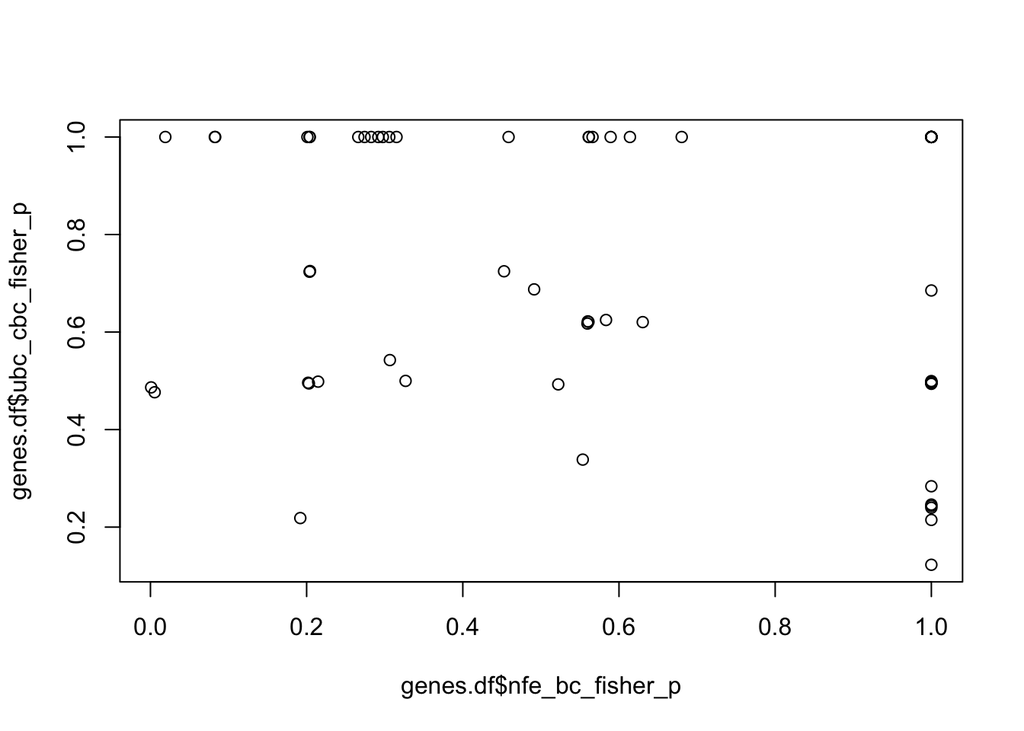

```r
# Plot different p-values against each other
plot(genes.df$nfe_bc_fisher_p, genes.df$ubc_cbc_fisher_p)
```

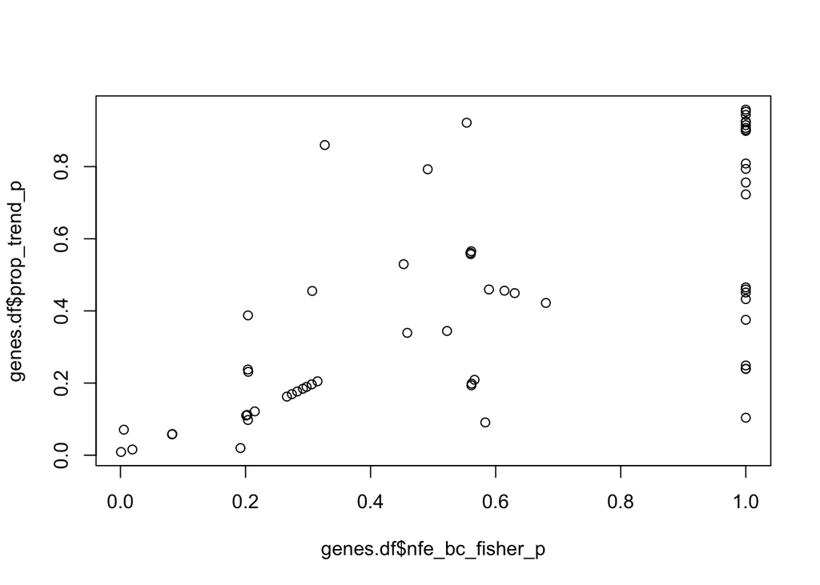

```r
plot(genes.df$nfe_bc_fisher_p, genes.df$prop_trend_p)
```

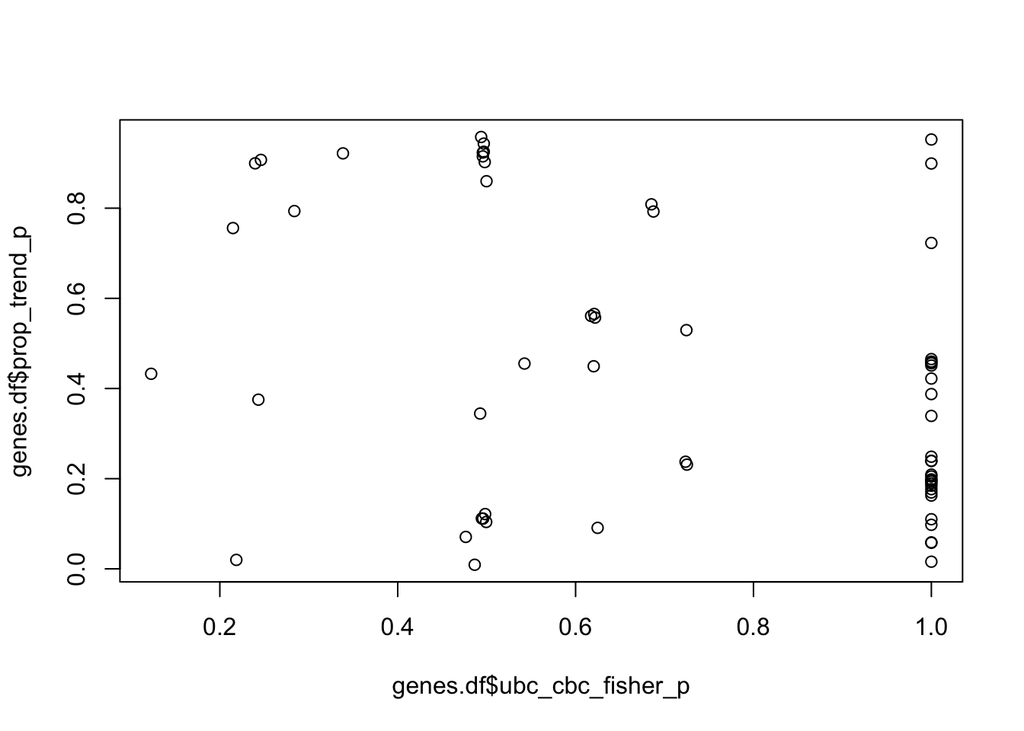

```r
plot(genes.df$ubc_cbc_fisher_p, genes.df$prop_trend_p)
```

# Crude “risk” candidates

*SETX* still is much more present in WECARE-Ampliseq than in NFE  
Similarly, *BRIP1* is absent in NFE, but present in WECARE-Ampliseq

```r
# Top "BC risk" candidates

genes.df %>%
  filter(crude_trend_direction=="Risk", nfe_bc_fisher_p < 0.05) %>%
  select(gene, aggr_af_nfe, aggr_af_ubc, aggr_af_cbc, nfe_bc_fisher_p, ubc_cbc_fisher_p,
         prop_trend_p, nfe_bc_fisher_fdr, ubc_cbc_fisher_fdr, prop_trend_fdr) %>%
  arrange(nfe_bc_fisher_p)
```

```
##   gene aggr_af_nfe aggr_af_ubc aggr_af_cbc nfe_bc_fisher_p ubc_cbc_fisher_p prop_trend_p nfe_bc_fisher_fdr ubc_cbc_fisher_fdr prop_trend_fdr
## 1 SETX           0 0.002439024 0.001677048     0.005402611        0.4765483   0.07080364         0.1674809                  1      0.5498864
```

```r
a <- genes.df %>% filter(crude_trend_direction=="Risk", nfe_bc_fisher_p < 0.05) %>% select(gene)

# Top "CBC risk" candidates
genes.df %>%
  filter(crude_trend_direction=="Risk", ubc_cbc_fisher_p < 0.05) %>%
  select(gene, aggr_af_nfe, aggr_af_ubc, aggr_af_cbc, nfe_bc_fisher_p, ubc_cbc_fisher_p,
         prop_trend_p, nfe_bc_fisher_fdr, ubc_cbc_fisher_fdr, prop_trend_fdr) %>%
  arrange(ubc_cbc_fisher_p)
```

```
##  [1] gene               aggr_af_nfe        aggr_af_ubc        aggr_af_cbc        nfe_bc_fisher_p    ubc_cbc_fisher_p   prop_trend_p       nfe_bc_fisher_fdr  ubc_cbc_fisher_fdr prop_trend_fdr
## <0 rows> (or 0-length row.names)
```

```r
b <- genes.df %>% filter(crude_trend_direction=="Risk", ubc_cbc_fisher_p < 0.05) %>% select(gene)

# Top "trend risk" candidates
genes.df %>%
  filter(crude_trend_direction=="Risk", prop_trend_p < 0.05) %>%
  select(gene, aggr_af_nfe, aggr_af_ubc, aggr_af_cbc, nfe_bc_fisher_p, ubc_cbc_fisher_p,
         prop_trend_p, nfe_bc_fisher_fdr, ubc_cbc_fisher_fdr, prop_trend_fdr) %>%
  arrange(prop_trend_p)
```

```
##    gene aggr_af_nfe  aggr_af_ubc aggr_af_cbc nfe_bc_fisher_p ubc_cbc_fisher_p prop_trend_p nfe_bc_fisher_fdr ubc_cbc_fisher_fdr prop_trend_fdr
## 1 BRIP1           0 0.0003808073 0.001875469        0.191905        0.2185646   0.01986061         0.8807448                  1      0.4104526
```

```r
c <- genes.df %>% filter(crude_trend_direction=="Risk", prop_trend_p < 0.05) %>% select(gene)

# Intersects

intersect(a,b)
```

```
## [1] gene
## <0 rows> (or 0-length row.names)
```

```r
intersect(b,c)
```

```
## [1] gene
## <0 rows> (or 0-length row.names)
```

```r
intersect(a,c)
```

```
## [1] gene
## <0 rows> (or 0-length row.names)
```

```r
# Clean-up
rm(a,b,c)
```

# Crude “protective” candidates

Anyway: it does not make sence to look at “protective” in low-frequency,  
because should not be rare, if beneficial …

```r
# Top "BC protective" candidates
genes.df %>%
  filter(crude_trend_direction=="Protective", nfe_bc_fisher_p < 0.05) %>%
  select(gene, aggr_af_nfe, aggr_af_ubc, aggr_af_cbc, nfe_bc_fisher_p, ubc_cbc_fisher_p,
         prop_trend_p, nfe_bc_fisher_fdr, ubc_cbc_fisher_fdr, prop_trend_fdr) %>%
  arrange(nfe_bc_fisher_p)
```

```
##    gene aggr_af_nfe aggr_af_ubc aggr_af_cbc nfe_bc_fisher_p ubc_cbc_fisher_p prop_trend_p nfe_bc_fisher_fdr ubc_cbc_fisher_fdr prop_trend_fdr
## 1 DCHS2 0.009280742 0.003438114  0.00458273    0.0009133556        0.4865565  0.009031143        0.05662804                  1      0.4104526
## 2 GBGT1 0.008823529 0.000000000  0.00000000    0.0190638547        1.0000000  0.015843173        0.39398633                  1      0.4104526
```

```r
a <- genes.df %>% filter(crude_trend_direction=="Protective", nfe_bc_fisher_p < 0.05) %>% select(gene)

# Top "CBC protective" candidates
genes.df %>%
  filter(crude_trend_direction=="Protective", ubc_cbc_fisher_p < 0.05) %>%
  select(gene, aggr_af_nfe, aggr_af_ubc, aggr_af_cbc, nfe_bc_fisher_p, ubc_cbc_fisher_p,
         prop_trend_p, nfe_bc_fisher_fdr, ubc_cbc_fisher_fdr, prop_trend_fdr) %>%
  arrange(ubc_cbc_fisher_p)
```

```
##  [1] gene               aggr_af_nfe        aggr_af_ubc        aggr_af_cbc        nfe_bc_fisher_p    ubc_cbc_fisher_p   prop_trend_p       nfe_bc_fisher_fdr  ubc_cbc_fisher_fdr prop_trend_fdr
## <0 rows> (or 0-length row.names)
```

```r
b <- genes.df %>% filter(crude_trend_direction=="Protective", ubc_cbc_fisher_p < 0.05) %>% select(gene)

# Top "trend protective" candidates
genes.df %>%
  filter(crude_trend_direction=="Protective", prop_trend_p < 0.05) %>%
  select(gene, aggr_af_nfe, aggr_af_ubc, aggr_af_cbc, nfe_bc_fisher_p, ubc_cbc_fisher_p,
         prop_trend_p, nfe_bc_fisher_fdr, ubc_cbc_fisher_fdr, prop_trend_fdr) %>%
  arrange(prop_trend_p)
```

```
##    gene aggr_af_nfe aggr_af_ubc aggr_af_cbc nfe_bc_fisher_p ubc_cbc_fisher_p prop_trend_p nfe_bc_fisher_fdr ubc_cbc_fisher_fdr prop_trend_fdr
## 1 DCHS2 0.009280742 0.003438114  0.00458273    0.0009133556        0.4865565  0.009031143        0.05662804                  1      0.4104526
## 2 GBGT1 0.008823529 0.000000000  0.00000000    0.0190638547        1.0000000  0.015843173        0.39398633                  1      0.4104526
```

```r
c <- genes.df %>% filter(crude_trend_direction=="Protective", prop_trend_p < 0.05) %>% select(gene)

# DCHS2 and GBGT1 are "Protective" because of the NFE vs WECARE change

# Intersects
intersect(a,b)
```

```
## [1] gene
## <0 rows> (or 0-length row.names)
```

```r
intersect(b,c)
```

```
## [1] gene
## <0 rows> (or 0-length row.names)
```

```r
intersect(a,c)
```

```
##    gene
## 1 DCHS2
## 2 GBGT1
```

```r
# Clean-ups
rm(a,b,c)
```

# QQ-plots

Assuming uniform p-value distributions under the null-hypothesis

```r
# nfe_bc_fisher_p
min(genes.df$nfe_bc_fisher_p)
```

```
## [1] 0.0009133556
```

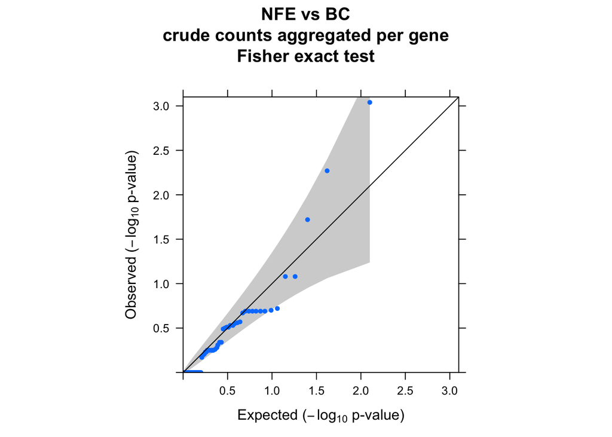

```r
p_obs <- genes.df$nfe_bc_fisher_p
p_exp <- ppoints(p_obs)
cptn="NFE vs BC\ncrude counts aggregated per gene\nFisher exact test"

qqunif.plot(p_obs, main=cptn)
```

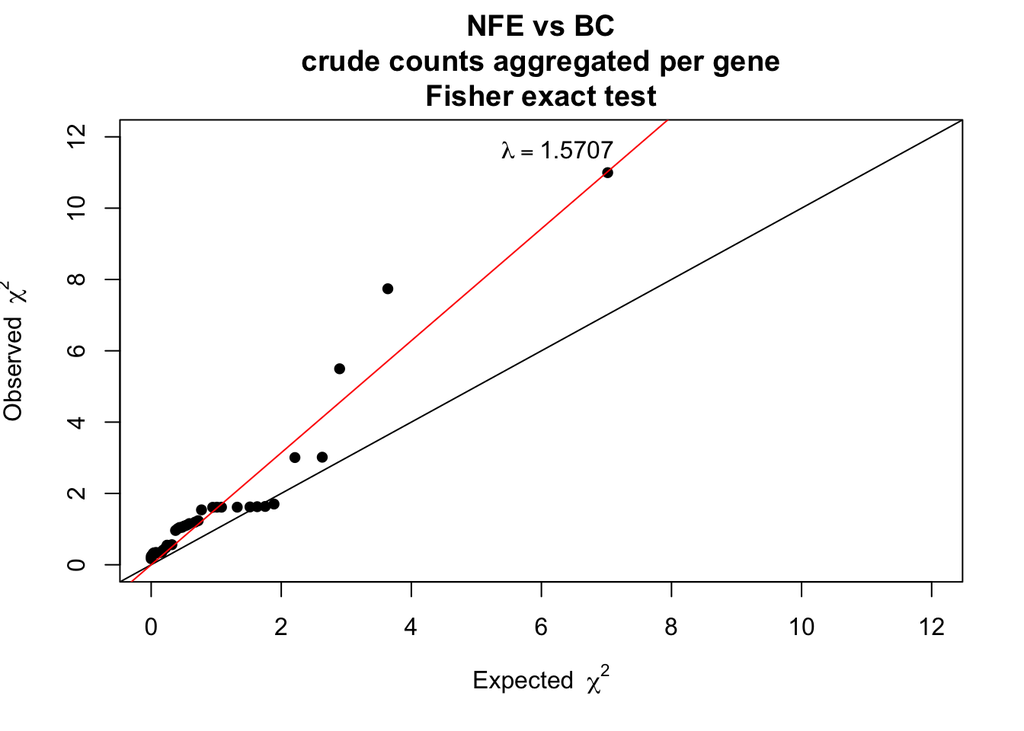

```
## $estimate
## [1] 1.570722
##
## $se
## [1] 0.05651641
```

```r
estlambda2(p.o=p_obs, p.e=p_exp, plot=T, main=cptn)
```

```r
# ubc_cbc_fisher_p
min(genes.df$ubc_cbc_fisher_p)
```

```
## [1] 0.1227954
```

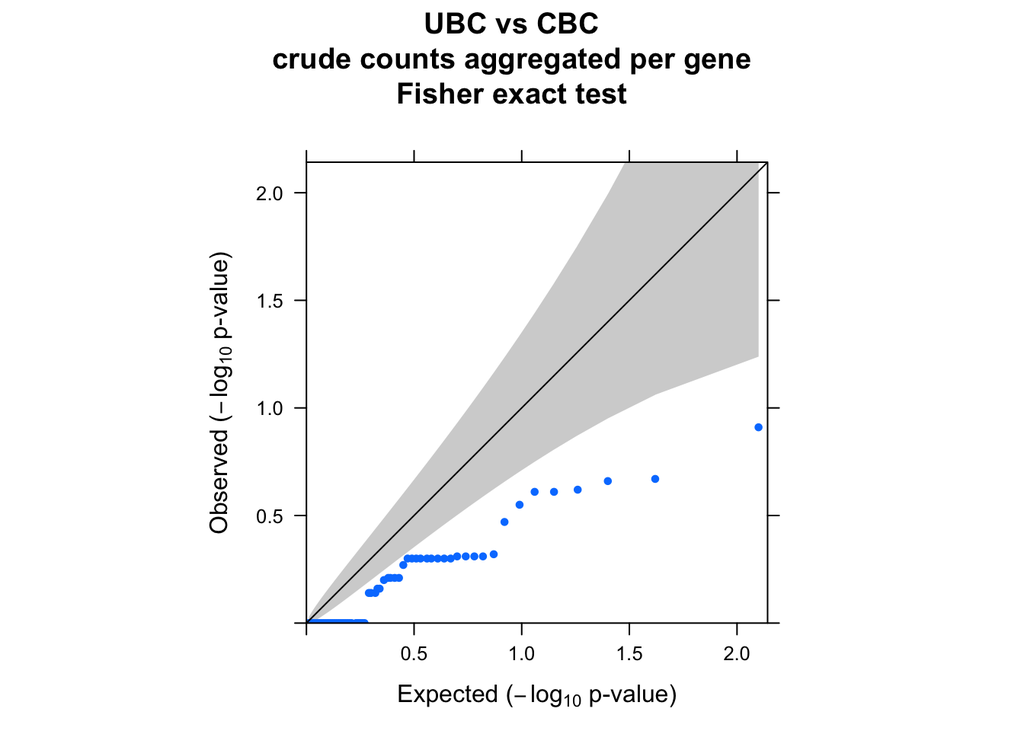

```r
p_obs <- genes.df$ubc_cbc_fisher_p
p_exp <- ppoints(p_obs)
cptn="UBC vs CBC\ncrude counts aggregated per gene\nFisher exact test"

qqunif.plot(p_obs, main=cptn)
```

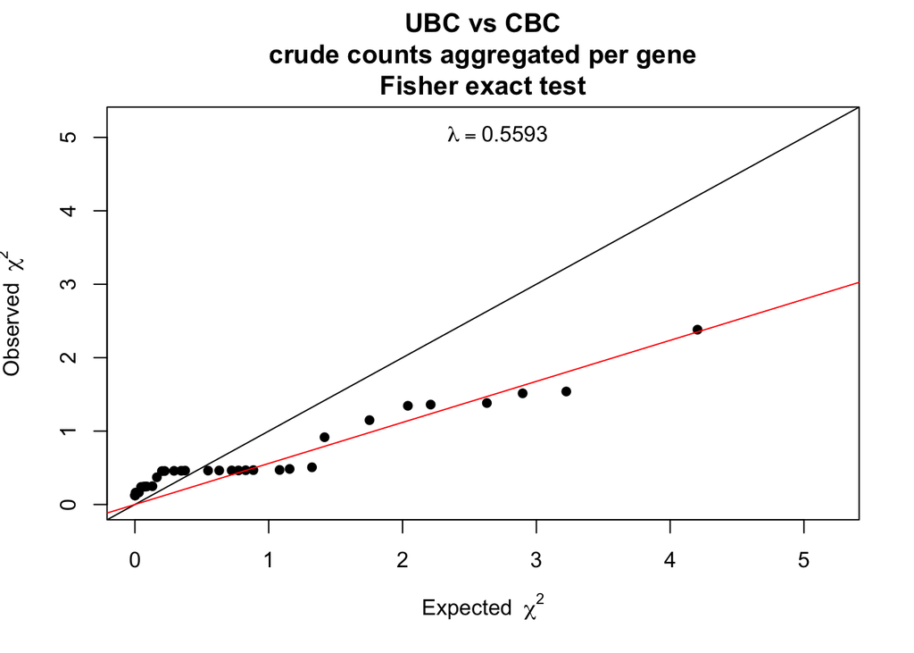

```
## $estimate
## [1] 0.5592805
##
## $se
## [1] 0.02340808
```

```r
estlambda2(p.o=p_obs, p.e=p_exp, plot=T, main=cptn)
```

```r
# prop trend p
min(genes.df$prop_trend_p)
```

```
## [1] 0.009031143
```

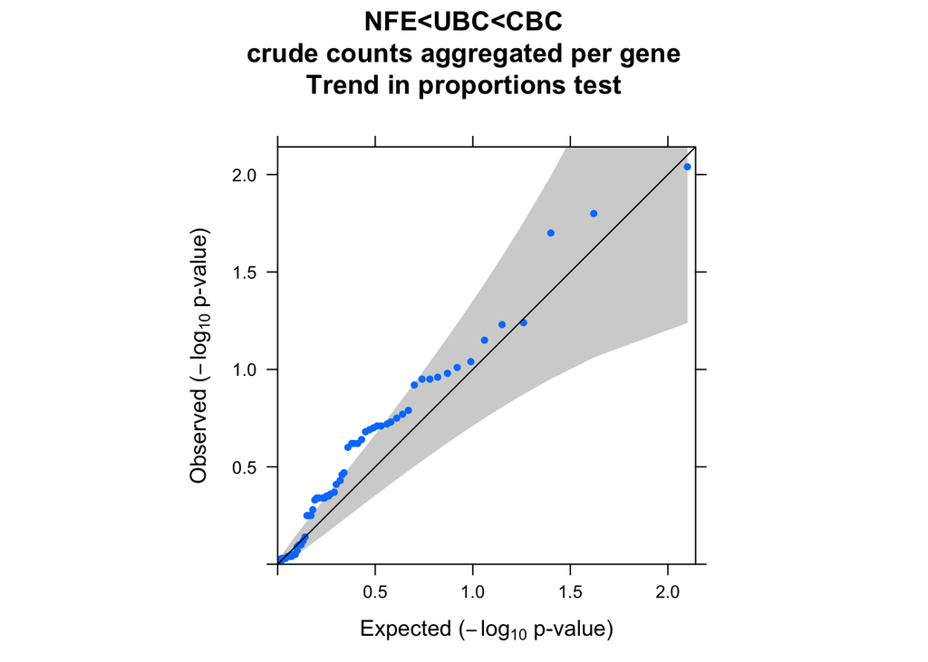

```r
p_obs <- genes.df$prop_trend_p
p_exp <- ppoints(p_obs)
cptn="NFE<UBC<CBC\ncrude counts aggregated per gene\nTrend in proportions test"

qqunif.plot(p_obs, main=cptn)
```

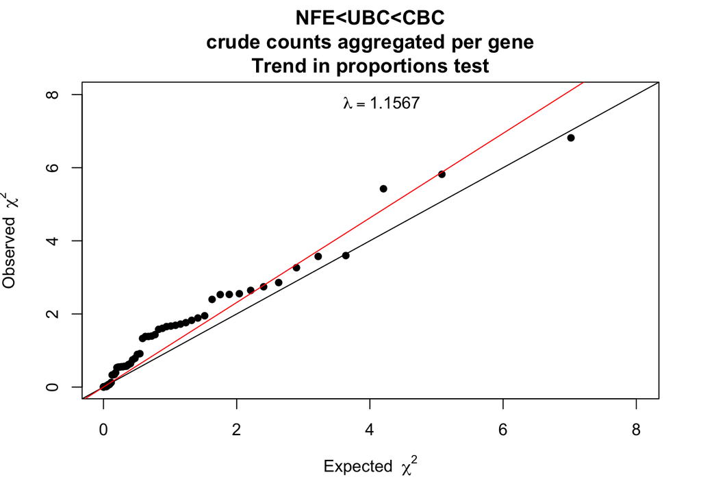

```
## $estimate
## [1] 1.156653
##
## $se
## [1] 0.02710241
```

```r
estlambda2(p.o=p_obs, p.e=p_exp, plot=T, main=cptn)
```

```r
# Clean-up
rm(qqunif.plot, p_obs, p_exp, cptn)
```

# explore_MACs

Crude allelic counts for ATM and CHEK2 are higher in BC than in NFE  
However, no further increase in CBC vs UBC (rather contrary for CHEK2)

```r
# Selected genes: candidates from previous analyses and
# GFRAL was an outlier, because of NFE >> UBC/CBC : likely methodical difference between KGEN and WECARE
genes.df[c("ATM","CHEK2"),
         c("aggr_ac", "aggr_ac_nfe", "aggr_ac_bc", "aggr_ac_ubc", "aggr_ac_cbc","crude_trend_direction")]
```

```
##       aggr_ac aggr_ac_nfe aggr_ac_bc aggr_ac_ubc aggr_ac_cbc crude_trend_direction
## ATM         7           0          7           3           4                  Risk
## CHEK2       4           1          3           3           0            Protective
```

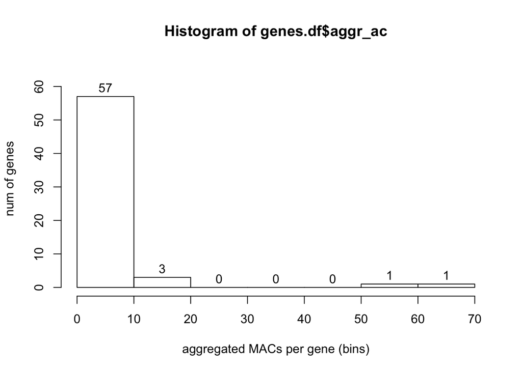

```r
# Histograms of aggregated MACs
hist(genes.df$aggr_ac, labels = TRUE, ylim=c(0,65),
     xlab="aggregated MACs per gene (bins)", ylab="num of genes")
```

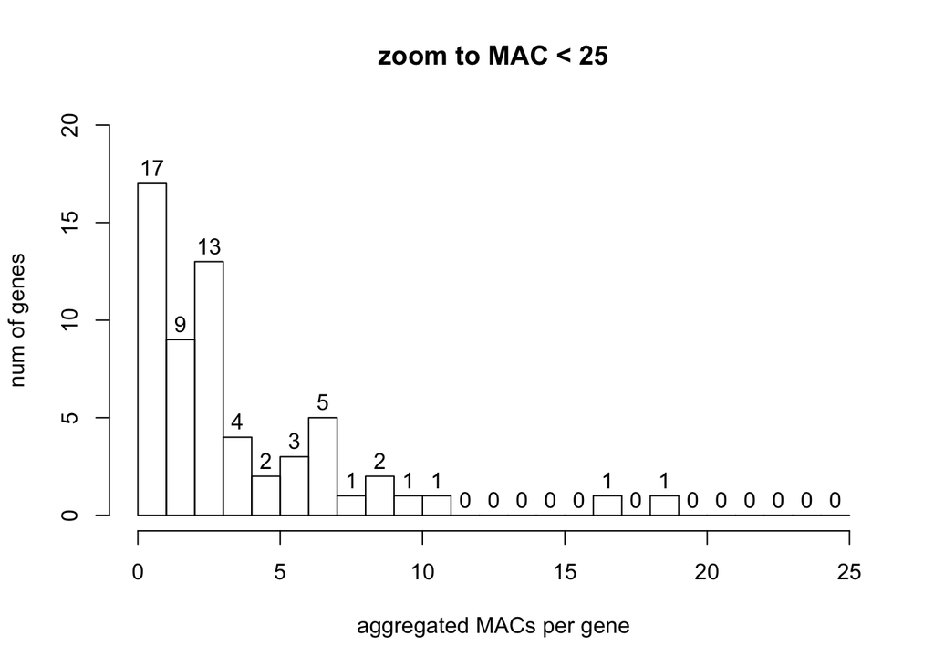

```r
hist(genes.df$aggr_ac[genes.df$aggr_ac<26], breaks=0:25,
     labels = TRUE, ylim=c(0,20), main="zoom to MAC < 25",
     xlab="aggregated MACs per gene", ylab="num of genes")
```

```r
mean(genes.df$aggr_ac)
```

```
## [1] 5.806452
```

```r
median(genes.df$aggr_ac)
```

```
## [1] 3
```

```r
# Genes with high MACs (non-weighted!)
x <- genes.df %>%
  select(gene, num_var, multiallelic, aggr_ac,
         aggr_af_nfe, aggr_af_ubc, aggr_af_cbc,
         nfe_bc_fisher_p, ubc_cbc_fisher_p,prop_trend_p,
         crude_trend_direction) %>%
  arrange(desc(aggr_ac))
x[1:10,]
```

```
##      gene num_var multiallelic aggr_ac  aggr_af_nfe  aggr_af_ubc  aggr_af_cbc nfe_bc_fisher_p ubc_cbc_fisher_p prop_trend_p crude_trend_direction
## 1   DCHS2       9        FALSE      65 0.0092807425 0.0034381139 0.0045827303    0.0009133556        0.4865565  0.009031143            Protective
## 2  RNF133       1        FALSE      59 0.0511363636 0.0366379310 0.0510638298    0.5536093171        0.3384391  0.921619835            Protective
## 3    DSG1       4        FALSE      19 0.0027063599 0.0038546256 0.0043057051    0.6140412957        1.0000000  0.456047612                  Risk
## 4    SETX       9        FALSE      17 0.0000000000 0.0024390244 0.0016770484    0.0054026110        0.4765483  0.070803643                  Risk
## 5  RNF128       1        FALSE      11 0.0028901734 0.0131578947 0.0085836910    0.3066023638        0.5425285  0.455325783                  Risk
## 6   RECQL       6         TRUE      10 0.0017793594 0.0007457122 0.0014482259    0.4913504394        0.6875303  0.792622835            Protective
## 7   EPHB2       1        FALSE       9 0.0027322404 0.0086206897 0.0085106383    0.4586216854        1.0000000  0.339178219                  Risk
## 8   CENPJ       6        FALSE       9 0.0009191176 0.0018896447 0.0007401925    1.0000000000        0.2837906  0.793617295            Protective
## 9    SLX4       4        FALSE       8 0.0006666667 0.0021574973 0.0015974441    0.4528058166        0.7246140  0.529530549                  Risk
## 10    ATR       6        FALSE       7 0.0000000000 0.0015174507 0.0011144131    0.2037609981        0.7236213  0.237569870                  Risk
```

```r
# Aggregated counts < 10 - too rare for stat analysis ??
sum(genes.df$aggr_ac < 10)
```

```
## [1] 56
```

```r
# Genes that may be analysed
sum(genes.df$aggr_ac >= 10)
```

```
## [1] 6
```

```r
# clean-up
rm(x)
```

# data_summary

```r
ls()
```

```
## [1] "base_folder"   "genes.df"      "genotypes.mx"  "phenotypes.df" "variants.df"
```

```r
dim(genotypes.mx)
```

```
## [1] 162 664
```

```r
dim(variants.df)
```

```
## [1] 162  87
```

```r
dim(phenotypes.df)
```

```
## [1] 664  31
```

```r
dim(genes.df)
```

```
## [1] 62 25
```

```r
# Check consistency of rownames and colnames
sum(colnames(genotypes.mx) != rownames(phenotypes.df))
```

```
## [1] 0
```

```r
sum(rownames(genotypes.mx) != rownames(variants.df))
```

```
## [1] 0
```

# save_data

```r
save.image(paste(base_folder, "s02_crude_genes_stats.RData", sep="/"))
```

# final_section

```r
ls()
```

```
## [1] "base_folder"   "genes.df"      "genotypes.mx"  "phenotypes.df" "variants.df"
```

```r
Sys.time()
```

```
## [1] "2019-09-19 18:25:38 BST"
```